# Resolução do Protocolo de Prática – Minicurso Introdução ao R

## Autor: Bruno Garcia Piato

#### **Seção 1: Explorando objetos no R**

**1. Criar e manipular vetores**

1. Crie um vetor contendo os nomes de alguns integrantes do curso.

```r
nomes <- c("Bruno", "Daubian", "Stephanie", "Charles", "Max")
```

2. Delete o 4º nome.

```r
nomes <- nomes[-4]
```

3. Adicione novamente este nome ao final do vetor.

```r
nomes[5] <- "Charles"
```

**2. Criar e manipular matrizes**

```r
matriz1 <- matrix(ncol = 3, nrow = 3, seq(1:9), byrow = FALSE)
```

2. Crie uma matriz 3x3 contendo valores sequenciais de 1 a 9 distribuídos por linha.

```r
matriz2 <- matrix(ncol = 3, nrow = 3, seq(1:9), byrow = TRUE)
```

3. Some as duas matrizes.

```r
matriz1 + matriz2
```

4. Multiplique a primeira matriz por 2.

```r
matriz1 * 2
```

**3. Criar e manipular dataframes**

1. Crie um dataframe contendo o nome de cada aluno, sua idade, titulação acadêmica e linha principal de pesquisa.

```r
dataframe <- data.frame(Nomes = c("Bruno","Daubian","Stephanie","Charles","Max"), Idade = c(28, 26, 25, 36, 36), Titulo = c("MSc","MSc","MSc","PhD","MSc"), Linha_Pesquisa = c("Filogeografia","Sistematica","Paleontologia","Sistematica","Biologia Molecular"), stringsAsFactors = FALSE) # O argumento stringsAsFactors = FALSE é importante para que a função data.frame() não transforme as variáveis Nomes e Linha_Pesquisa em fatores, impedindo a entrada posterior de termos contendo mais de uma palavra. Teste este e o próximo passos mudando este argumento para TRUE
```

2. Adicione ao dataframe uma linha contendo as informações do Dr. Willi Hennig aos 42 anos, quando publicou seu trabalho seminal sobre sistemática filogenética.

```r
dataframe[nrow(dataframe)+1,] <- c("Willi Hennig", "42", "PhD", "Sistematica")
```

3. Adicione uma coluna contendo o sexo de cada observação.

```r
dataframe <- cbind(dataframe, Sexo = c("M", "M", "F", "M", "M", "M"))
```

ou

```r
dataframe[5] <- c("M", "M", "F", "M", "M", "M")
colnames(dataframe)[5] <- "Sexo"
```

4. Transforme a coluna recém-adicionada em um fator.

```r
dataframe$Sexo <- factor(dataframe$Sexo)
class(dataframe$Sexo) # Para verificarmos se a mudança foi mesmo realizada
```

22. Selecione somente os participantes com mais de 30 anos.

```r
dataframe[dataframe$Idade>=30,]
```

ou

```r
dplyr::filter(dataframe, dataframe$Idade>=30)
```

6. Selecione somente os participantes que trabalhem com sistemática.

```r
dataframe[dataframe$Linha_Pesquisa=="Sistematica",]
```

7. Selecione os participantes que tenham mestrado ou doutorado.

```r
dataframe[dataframe$Titulo=="MSc"|dataframe$Titulo=="PhD",]
```

8. Selecione os participantes que tenham menos que 30 anos e trabalhem com biogeografia.

```r
dataframe[dataframe$Idade<=30 & dataframe$Linha_Pesquisa=="Biogeografia",]
```

**4. Criar listas**

1. Crie uma lista contendo dois itens: o dataframe completo do exercício anterior e um vetor booleano (verdadeiro ou falso) para se o participante consome ou não consome carne.

```r
lista <- list(Dados = dataframe, Veg = c(F, T, F, F, F, T))
```

2. Adicione à lista um vetor fatorial com V para os participantes vivos e M para os mortos.

```r
lista$Vivo_Morto <- c("V", "V", "V", "V", "V", "M")
```

3. Adicione os dois vetores recém-criados ao dataframe original.

```r
dataframe <- cbind(dataframe, Veg = lista$Veg, Vivo_Morto = lista$Vivo_Morto)
```

#### Seção 2: Importação, exploração e preparação de dados

**1. Importar dados**

1. Importe o arquivo Pokemons.csv para um dataframe no R.

```r
pokemons <- read.csv("C:/Users/admin/Dropbox/BIOLOGIA/R/MEU CURSO DE R/Material Minicurso Introdução ao R/Dados/Pokemons.csv") # Troque o caminho para a pasta em que o arquivo Pokemons.csv se encontra em seu computador. As informações foram baixada do site https://www.kaggle.com/alopez247/pokemon e retiradas do repositório de informações https://bulbapedia.bulbagarden.net/wiki/Main_Page
```

**2. Explorar inicialmente os dados**

1. Verifique a estrutura, o resumo, o início e o final dos dados. Transforme a coluna Name de fator para caracteres

```r
str(pokemons)
summary(pokemons)
head(pokemons, 10)
tail(pokemons, 10)
pokemons$Name <- as.character(pokemons$Name)
```

2. Quais são os Pokémons com maior e menor valores de pontos de vida (HP)?

```r
max(pokemons$HP)
pokemons[pokemons$HP == max(pokemons$HP),c(2, 6)]
min(pokemons$HP)
pokemons[pokemons$HP == min(pokemons$HP),c(2,6)]
```

3. Quais são os Pokémons com maior e menor ataques (Attack + Sp_Atk)?

```r
pokemons2 <- cbind(pokemons, ataque = pokemons$Sp_Atk + pokemons$Attack)
pokemons2[,c(2, 6, 9, 10, 24)]
pokemons2[pokemons2$ataque == max(pokemons2$ataque),c(2, 6, 7, 9, 24)]
pokemons2[pokemons2$ataque == min(pokemons2$ataque),c(2, 6, 7, 9, 24)]
```

4. Quais são os Pokémons com maior e menor defesas (Defense + Sp_Def)?

```r
pokemons3 <- cbind(pokemons2, defesa = pokemons$Sp_Def + pokemons$Defense)
pokemons3[,c(2, 6, 9, 10, 24)]
pokemons3[pokemons3$defesa == max(pokemons3$defesa),c(2, 6, 8, 10, 24)]
pokemons3[pokemons3$defesa == min(pokemons3$defesa),c(2, 6, 8, 10, 24)]
```

**3. Preparar dados**

1. Selecione somente os Pokémons lendários, criando um objeto somente com eles.

```r
lendarios <- pokemons3[pokemons3$isLegendary == "True",]
```

2. Quais Pokémons lendários têm maior probabilidade de captura (Catch_Rate/255)?

```r
lendarios[lendarios$Catch_Rate == max(lendarios$Catch_Rate), c(2, 6, 9, 10, 22, 24, 25)]
```

ou

```r
head(dplyr::arrange(lendarios, desc(Catch_Rate)))
```

3. Organize os Pokémons lendários em ordem alfabética.

```r
dplyr::arrange(lendarios, Name)
```

4. Organize os Pokémons lendários em ordem decrescente da soma de todas as características (variável Total).

```r
dplyr::arrange(lendarios, desc(Total))
```

22. Amostre aleatoriamente cinco Pokémons lendários (antes de implementar a linha para o sorteio, use a função set.seed(123) para garantir que o resultado de todos seja o mesmo e replicável).

```r
set.seed(123)
dplyr::sample_n(lendarios, 5)
```

```r
dplyr::count(lendarios, Type_1)
```

Mais funções e usos do pacote *dplyr* podem ser encontradas no site https://www3.nd.edu/~steve/computing_with_data/24_dplyr/dplyr.html

#### Seção 3: Visualização de dados

**1. Plotar diferentes tipos de gráficos com ggplot2**

1. Faça um gráfico de dispersão dos pontos de ataque (Attack) pelos pontos de defesa (Defense), colorindo de acordo com seu tipo primário (Type_1).

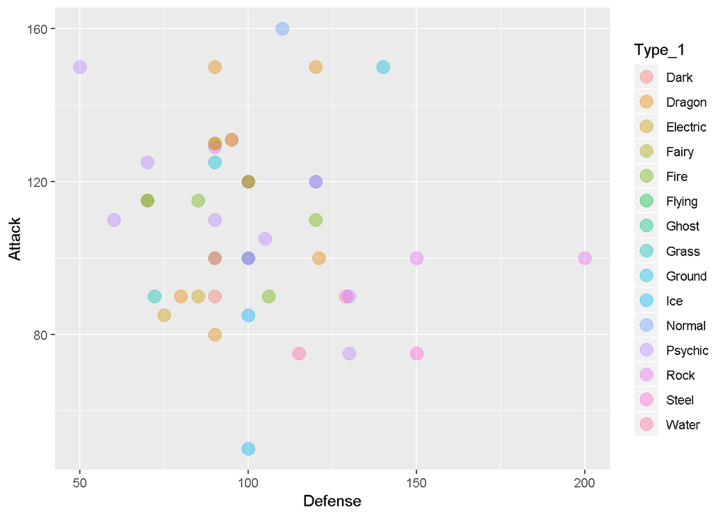

```r
library(ggplot2)
ggplot(lendarios) + geom_point(aes(x = Defense, y = Attack, color = Type_1), size = 4, alpha = 0.4)
```

2. Faça um gráfico de caixa (boxplot) dos pontos de vida (HP) de acordo com o tipo primário (Type_1) do Pokémon.

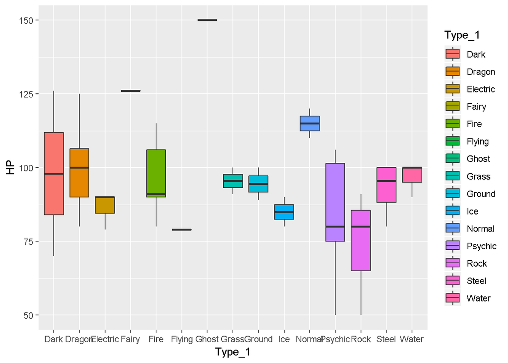

```r
ggplot(lendarios) + geom_boxplot(aes(y = HP, x = Type_1, fill = Type_1))
```

3. Faça um gráfico de pizza para as proporções dos tipos primários (Type_1) de Pokémons.

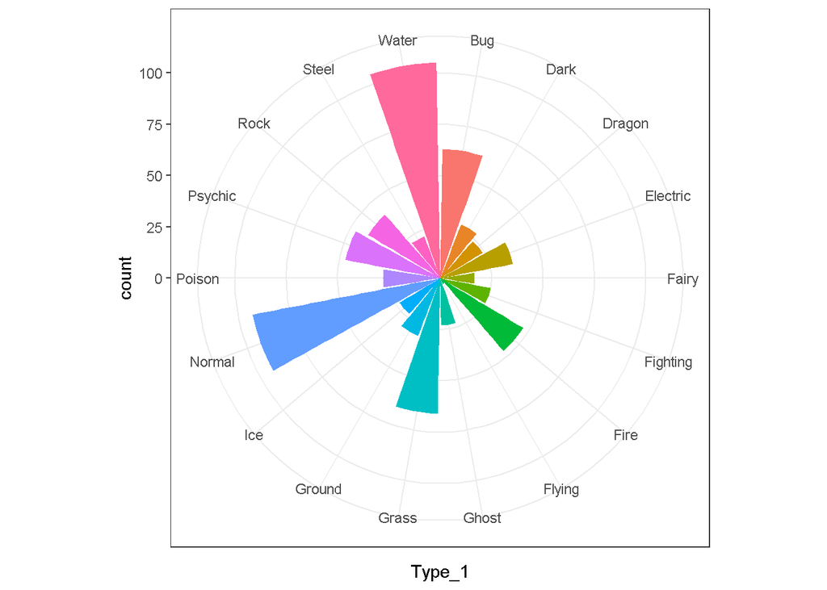

```r
ggplot(pokemons3) + geom_bar(aes(x = Type_1, fill = Type_1)) + coord_polar() + theme_bw() + theme(legend.position="none")
```

ou

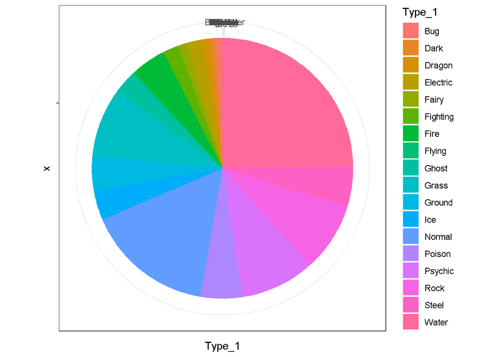

```r
ggplot(pokemons3) + geom_bar(aes(x = "", y = Type_1, fill = Type_1), stat = "identity") + coord_polar("y", start=0) + theme_bw()
```

4. Qual é a melhor evolução do Eevee (Jolteon, Flareon, Vaporeon, Umbreon, Espeon, Leafeon, Glaceon ou Sylveon) com base em seus pontos somados (Total)? Plote quatro gráficos de colunas (*geom_col()*), um para pontos de ataque (Attack), uma para pontos de ataque especial (Sp_Atk), um para pontos de defesa (Defense) e um para defesa especial (Sp_Def), colorindo as barras de acordo com a espécie (*scale_fill_manual(values = c()*).

```r
eevee_evo <- pokemons3[pokemons3$Name == "Jolteon" | pokemons3$Name == "Flareon" | pokemons3$Name == "Vaporeon" | pokemons3$Name ==  "Umbreon" | pokemons3$Name ==  "Espeon" | pokemons3$Name ==  "Leafeon" | pokemons3$Name ==  "Glaceon" | pokemons3$Name ==  "Sylveon", ]

dplyr::arrange(eevee_evo, Total)
```

ou

[figure not shown]

```r
ggplot(eevee_evo) +
  geom_col(aes(y = Total, x = Name, fill = Name), col = "black") +
  scale_fill_manual(values = c("darkorchid1", "firebrick2", "paleturquoise1", "goldenrod1", "green3", "ghostwhite", "gray12", "deepskyblue4")) +
  ggtitle(label = "Total") +
  theme_bw() +
  theme(plot.title = element_text(hjust = 0.5))
```

[figure not shown]

```r
ggplot(eevee_evo) +
  geom_col(aes(y = Attack, x = Name, fill = Name), col = "black") +
  scale_fill_manual(values = c("darkorchid1", "firebrick2", "paleturquoise1", "goldenrod1", "green3", "ghostwhite", "gray12", "deepskyblue4")) +
  ggtitle(label = "Ataque") +
  theme_bw() +
  theme(plot.title = element_text(hjust = 0.5))
```

[figure not shown]

```r
ggplot(eevee_evo) +
  geom_col(aes(y = Sp_Atk, x = Name, fill = Name), col = "black") +
  scale_fill_manual(values = c("darkorchid1", "firebrick2", "paleturquoise1", "goldenrod1", "green3", "ghostwhite", "gray12", "deepskyblue4")) +
  ggtitle(label = "Ataque Especial") +
  theme_bw() +
  theme(plot.title = element_text(hjust = 0.5))
```

[figure not shown]

```r
ggplot(eevee_evo) +
  geom_col(aes(y = Defense, x = Name, fill = Name), col = "black") +
  scale_fill_manual(values = c("darkorchid1", "firebrick2", "paleturquoise1", "goldenrod1", "green3", "ghostwhite", "gray12", "deepskyblue4")) +
  ggtitle(label = "Defesa") +
  theme_bw() +
  theme(plot.title = element_text(hjust = 0.5))
```

[figure not shown]

```r
ggplot(eevee_evo) +
  geom_col(aes(y = Sp_Def, x = Name, fill = Name), col = "black") +
  scale_fill_manual(values = c("darkorchid1", "firebrick2", "paleturquoise1", "goldenrod1", "green3", "ghostwhite", "gray12", "deepskyblue4")) +
  ggtitle(label = "Defesa Especial") +
  theme_bw() +
  theme(plot.title = element_text(hjust = 0.5))
```

22. Qual é, entre as evoluções do Eevee, o melhor atacante (Attack + Sp_Atk)?

[figure not shown]

```r
ggplot(eevee_evo) +
  geom_col(aes(y = (Sp_Atk+Attack), x = Name, fill = Name), col = "black") +
  scale_fill_manual(values = c("darkorchid1", "firebrick2", "paleturquoise1", "goldenrod1", "green3", "ghostwhite", "gray12", "deepskyblue4")) +
  ggtitle(label = "Ataque + Ataque Especial") +
  theme_bw() +
  theme(plot.title = element_text(hjust = 0.5))
```

6. Qual é, entre as evoluções do Eevee, o melhor defensor (Defense + Sp_Def)?

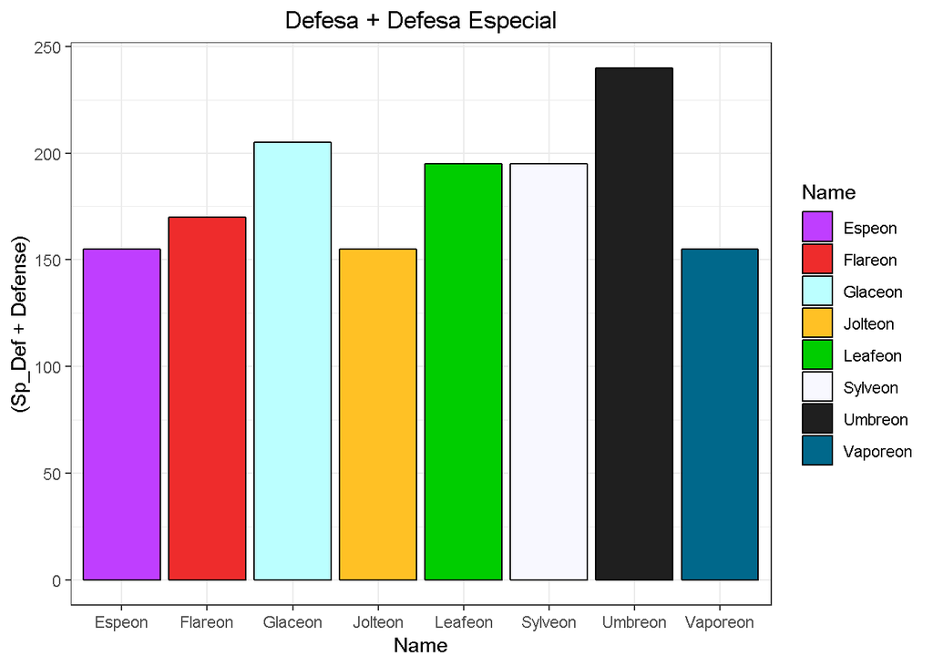

```r
ggplot(eevee_evo) +
  geom_col(aes(y = (Sp_Def+Defense), x = Name, fill = Name), col = "black") +
  scale_fill_manual(values = c("darkorchid1", "firebrick2", "paleturquoise1", "goldenrod1", "green3", "ghostwhite", "gray12", "deepskyblue4")) +
  ggtitle(label = "Defesa + Defesa Especial") +
  theme_bw() +
  theme(plot.title = element_text(hjust = 0.5))
```

#### Seção 4: Análises estatísticas e ecológicas básicas

**1. Estatísticas básicas**

1. Há correlação entre pontos de ataque (Attack) e de defesa (Defense) dos Pokémons? Plote o gráfico de correlação entre eles, ajustando uma reta de regressão linear.

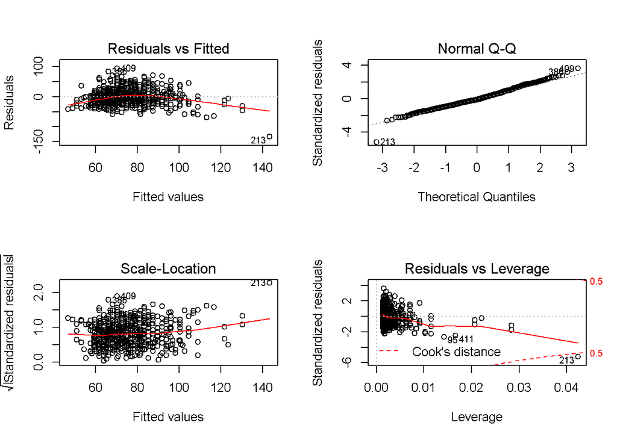

```r
ataqueVSdefesa_lm <- lm(pokemons3$Attack~pokemons3$Defense)
summary(ataqueVSdefesa_lm)
par(mfrow = c(2,2))
plot(ataqueVSdefesa_lm)
```

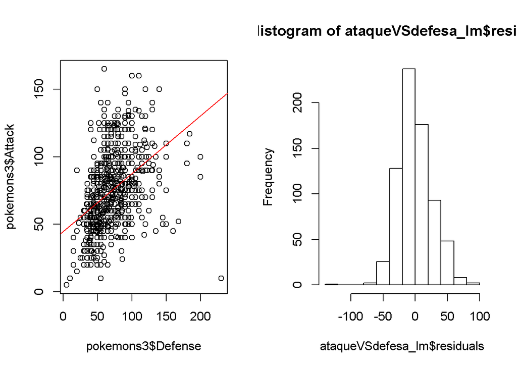

```r
par(mfrow = c(1,2))
plot(pokemons3$Attack~pokemons3$Defense)
abline(ataqueVSdefesa_lm, col = "red")
hist(ataqueVSdefesa_lm$residuals)
```

ou

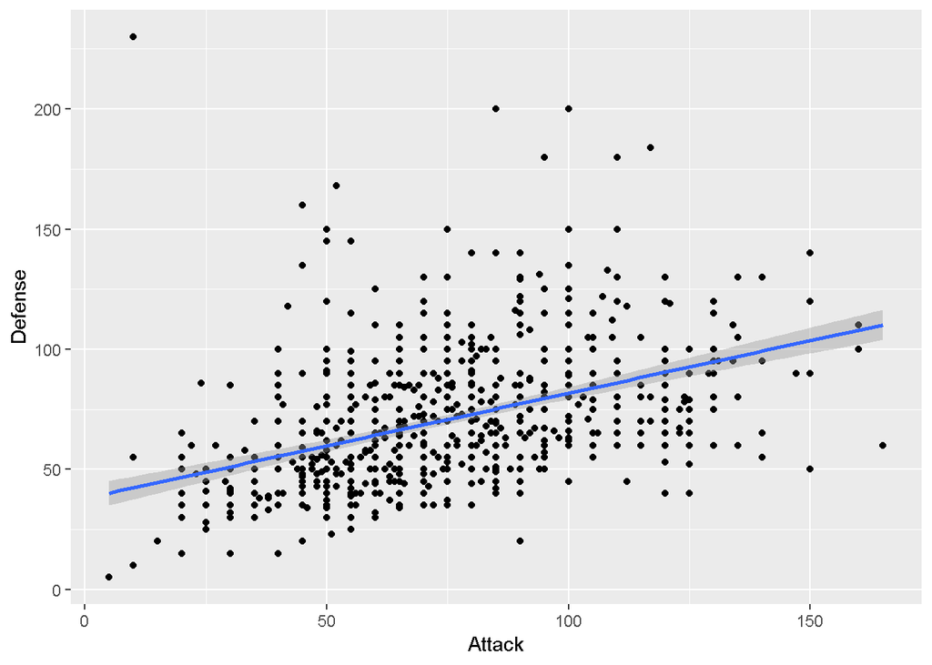

```r
library(ggplot2)
ggplot(pokemons3) + geom_point(aes(x = Attack, y = Defense)) + geom_smooth(method = "lm", aes(x = Attack, y = Defense))
```

2. Há correlação entre pontos de ataque (Attack) e pontos de ataque especial (Sp_Atk) dos Pokémons? Plote o gráfico de correlação entre eles, ajustando uma reta de regressão linear.

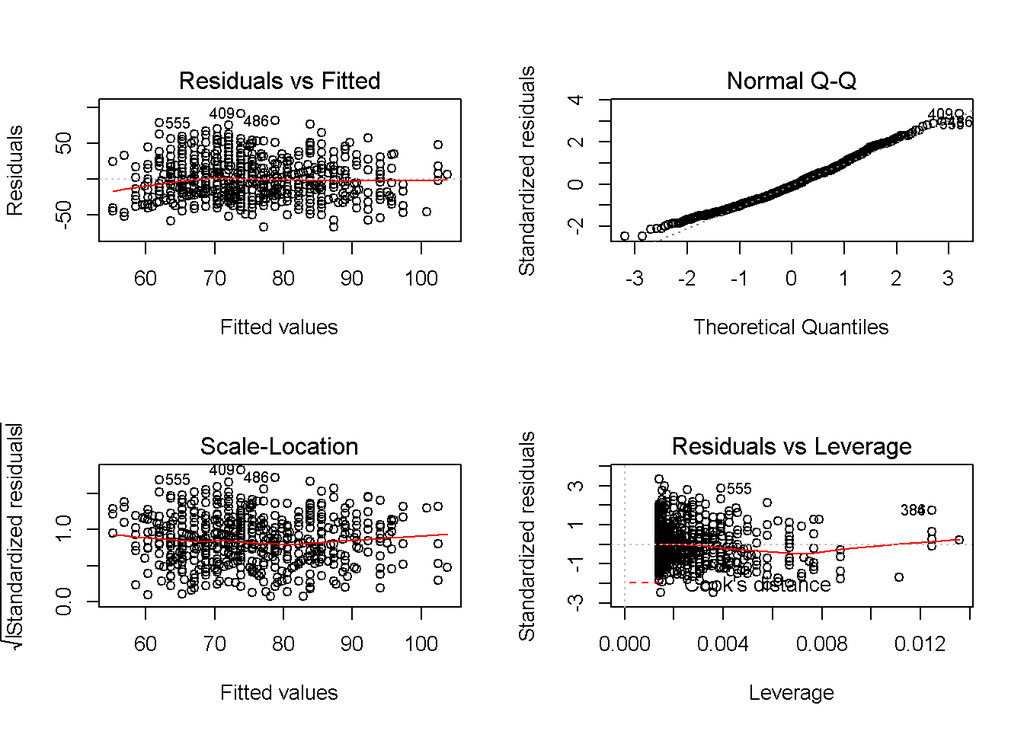

```r
ataque_lm <- lm(pokemons3$Attack~pokemons3$Sp_Atk)
summary(ataque_lm)
par(mfrow = c(2,2))
plot(ataque_lm)
```

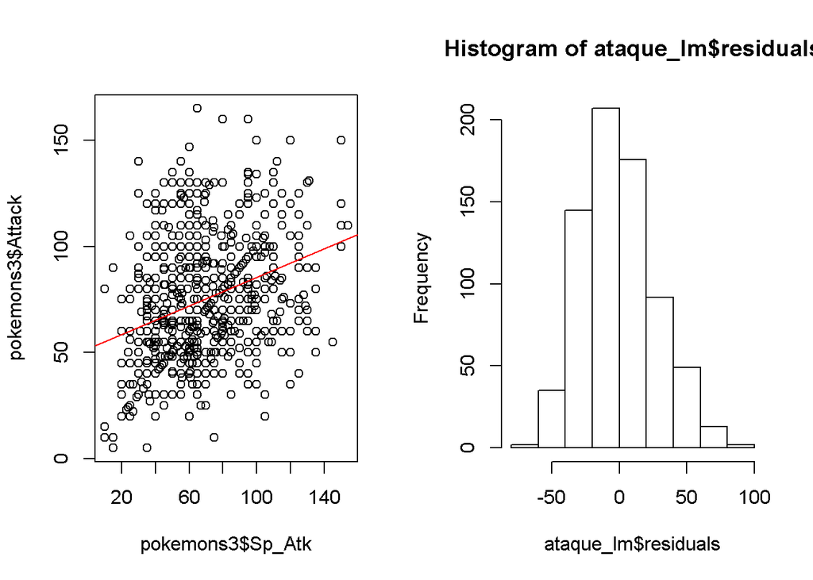

```r
par(mfrow = c(1,2))
plot(pokemons3$Attack~pokemons3$Sp_Atk)
abline(ataque_lm, col = "red")
hist(ataque_lm$residuals)
```

ou

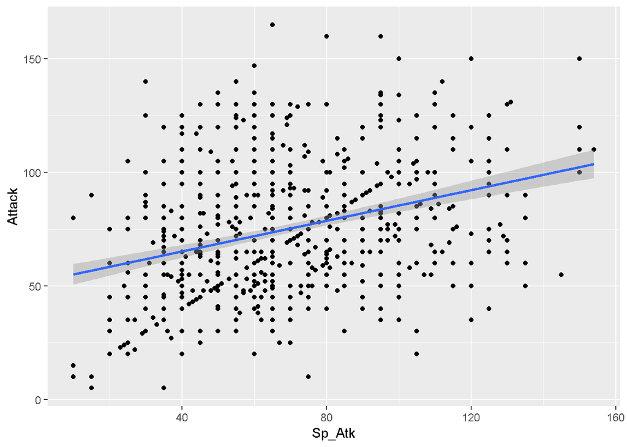

```r
ggplot(pokemons3) + geom_point(aes(x = Sp_Atk, y = Attack)) + geom_smooth(method = "lm", aes(x = Sp_Atk, y = Attack))
```

3. Há diferença entre os tipos primários (Type_1) de Pokémons quanto a seus pontos de vida, ou os diferentes tipos de Pokémons possuem mesma variação de pontos de vida?

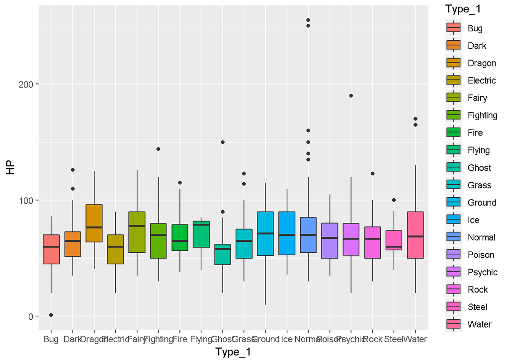

```r
anova_HP <- aov(HP~Type_1, data = pokemons3)
summary(anova_HP)
TukeyHSD(anova_HP) # Este teste pode ser utilizado para identificar entre quais níveis do fator estão as diferenças encontradas na ANOVA
ggplot(pokemons3) + geom_boxplot(aes(y = HP, x = Type_1, fill = Type_1)) # Podemos querer visualizar as diferenças encontradas pelo teste de ANOVA. Lembre-se, entretanto, que em boxplots, o traço no meio das caixas é a mediana, enquanto a ANOVA utiliza medidas de média para testas a hipótese nula (H0) de que não há diferença entre as médias dos níveis de um fator
```

4. Os pontos de vida dos Pokémons se apresentam como em uma distribuição normal? Plote um gráfico de barras da distribuição dos pontos de vida dos Pokémons em relação a sua frequência.

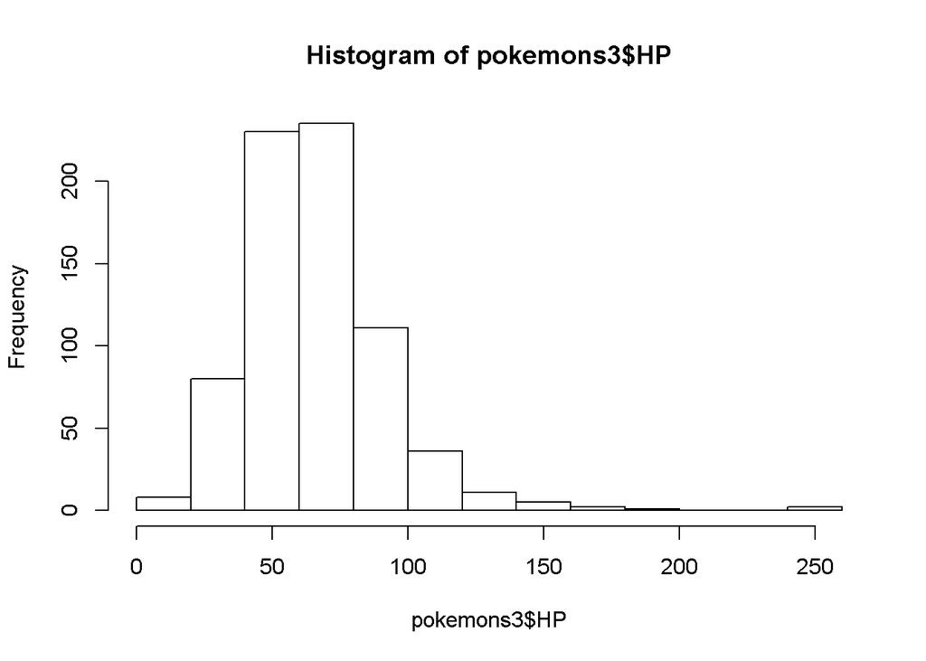

```r
shapiro.test(pokemons3$HP)
hist(pokemons3$HP)
```

ou

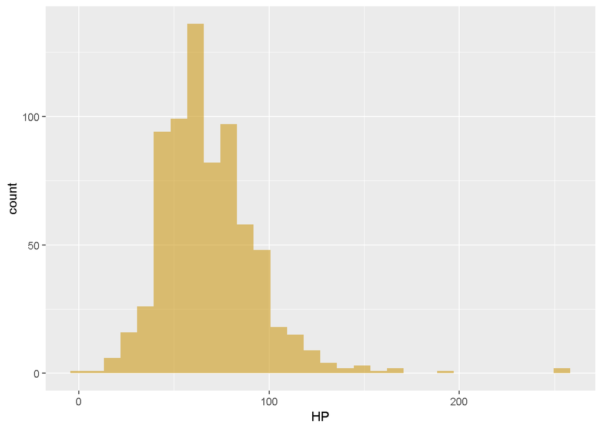

```r
ggplot(pokemons3) + geom_histogram(aes(x = HP), alpha = 0.6, fill = "goldenrod3")
```

**2. PCA com dados eco-morfológicos**

1. Carregue o conjunto de dados iris presente no pacote base do R. Veja a estrutura e o resumo dos dados e plote rapidamente um boxplot para cada variável morfológica de acordo com as espécies do gênero *Iris* para explorar inicialmente os dados. Que insights podemos tirar dessa visualização preliminar dos dados?

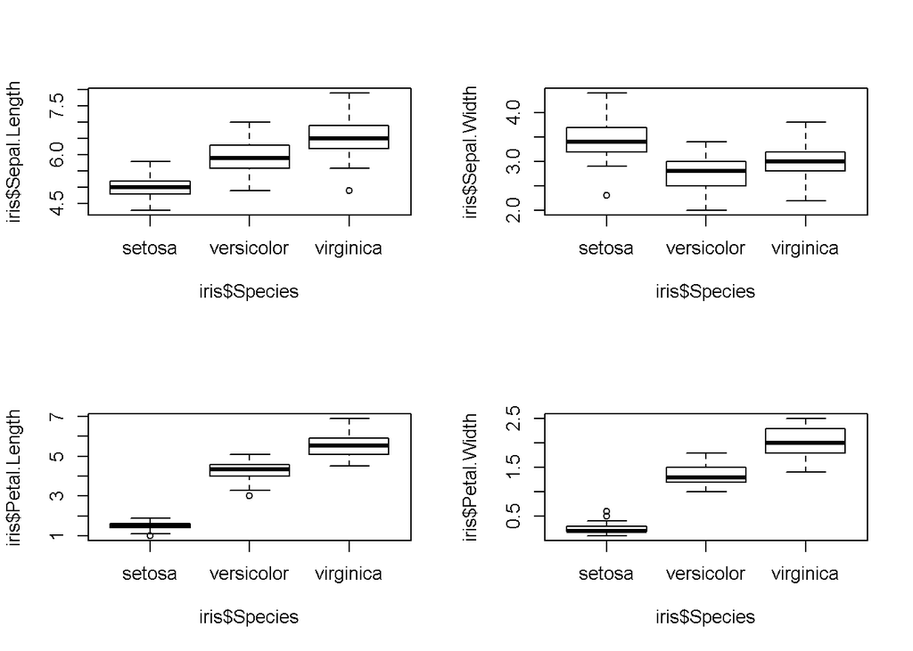

```r
data(iris)
summary(iris)
str(iris)
par(mfrow = c(2,2)) # Podemos usar a função par() para definir propriedades do dispositivo gráfico. Neste caso estamos definindo, no argumento mfrow, um vetor contendo o número de linhas e colunas, respectivamente que o dispositivo gráfico deve ter. Para resetar o dospositivo podemos usar a função dev.off()
boxplot(iris$Sepal.Length~iris$Species)
boxplot(iris$Sepal.Width~iris$Species)
boxplot(iris$Petal.Length~iris$Species)
boxplot(iris$Petal.Width~iris$Species)
```

2. Realize uma Análise de Componentes Principais (PCA) escalonada utilizando as quatro variáveis morfológicas e plote um gráfico do resultado dos dois principais componentes (PC1 e PC2), colorindo por espécie.

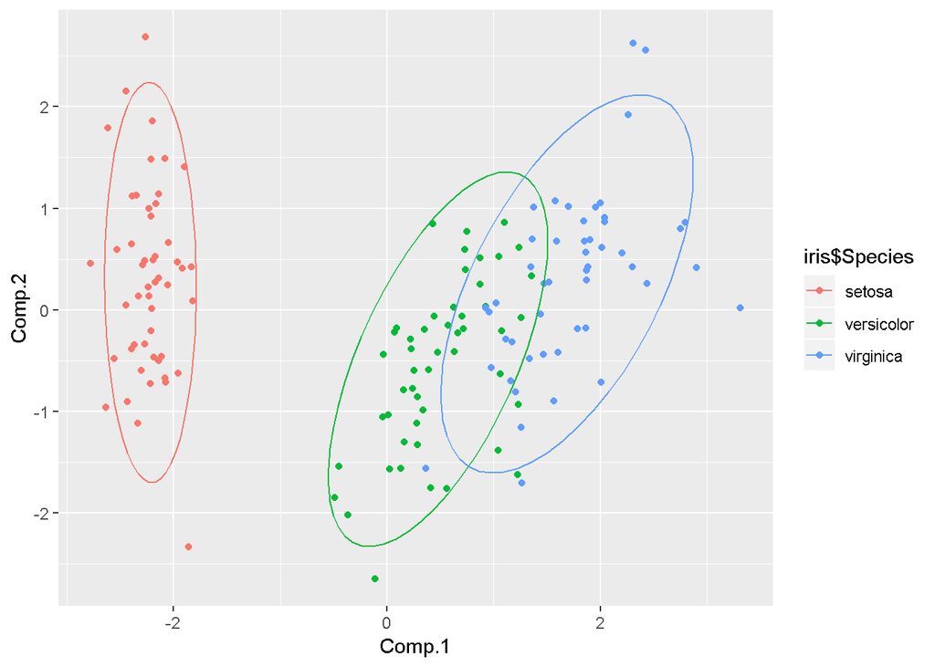

```r
PCAiris <- princomp(iris[,-5], cor = T)
library(ggplot2)
ggplot(as.data.frame(PCAiris$scores)) + geom_point(aes(x = Comp.1, y = Comp.2, col = iris$Species)) + stat_ellipse(aes(x = Comp.1, y = Comp.2, col = iris$Species))
```

**3. PCA com dados genéticos**

**4. Diversidade Filogenética**

#### Seção 5: Análises filogenéticas básicas

**1. Análise de máxima parcimônia**

**2. Análise de máxima verossimilhança**

#### Seção 6: Breves manipulações de mapas

**1. Importando rasters**

**2. Criando e cortando stacks**